# PTT推噓分析

### 機器學習導論期末專題

#### 105061225 周宣呈 105061254 林士平

##### (註：此code需要在code資料夾下才能執行)

### 一、專題目標

#### 針對不同的版，分析文章推噓數和特定關鍵字詞之間的關係。最終目標是針對不同版各訓練出一個模型，將文章丟入便可以推測它的推噓數區間。

### 二、專題流程

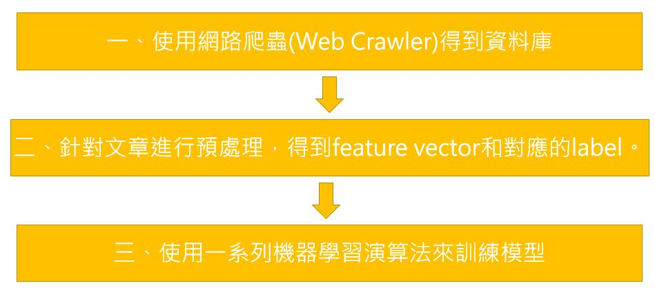

```python
from IPython.display import Image
Image(filename='image/專題流程.jpg', width=600)
```

### 三、專題內容 -- 網路爬蟲介紹

#### 1. 利用request得到網頁資料，再利用beautiful soup從html格式擷取我們需要的資訊。

#### 2. 我們找了ptt較熱門的11個版，而且沒有封鎖推噓功能。

#### 3. 由於ptt上有些版是18+的，所以爬蟲程式中需要額外做自動通過18+的確認動作。

#### 4. 我們每個版的data做200頁，非18+的版需要40分鐘、18+的版需要90分鐘。

#### 5. 得到了11個database，文章的推文數-噓文數為label，文章內文去除引用及推噓文內容為feature。

#### 下圖為database基本資料與對應的code：

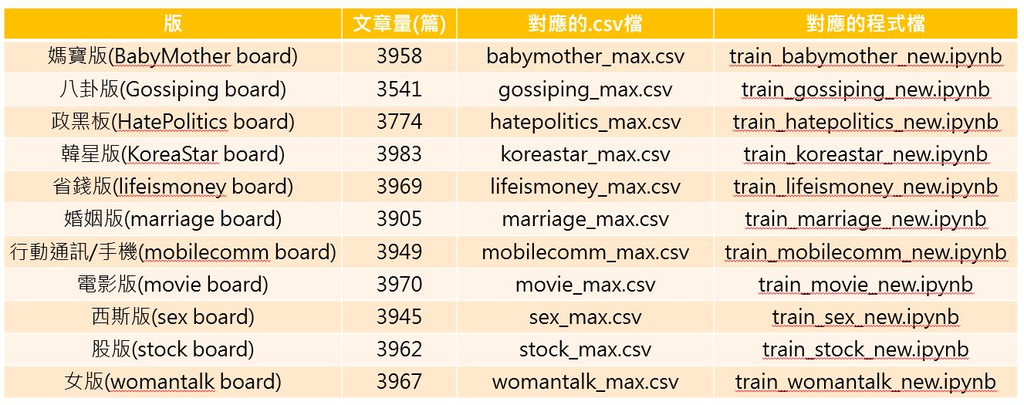

```python
from IPython.display import Image
Image(filename='image/專題資料庫簡介.jpg', width=1000)
```

##### (註：網路爬蟲程式檔見code/Web Crawler.ipynb；database檔案均在code資料夾中)

### 四、專題內容 -- 預處理、萃取feature vector 與label encoding

##### (註：此報告將以train_gossiping_new.ipynb為例子，其餘的程式檔案見code資料夾)

```python
# read database
import pandas as pd

f = open('gossiping_max.csv')
df= pd.read_csv(f, header = None)
df = df.fillna('0')

X = df.iloc[:, 2].values
y = df.iloc[:, 1].values
```

#### 文章處理的步驟如下圖：

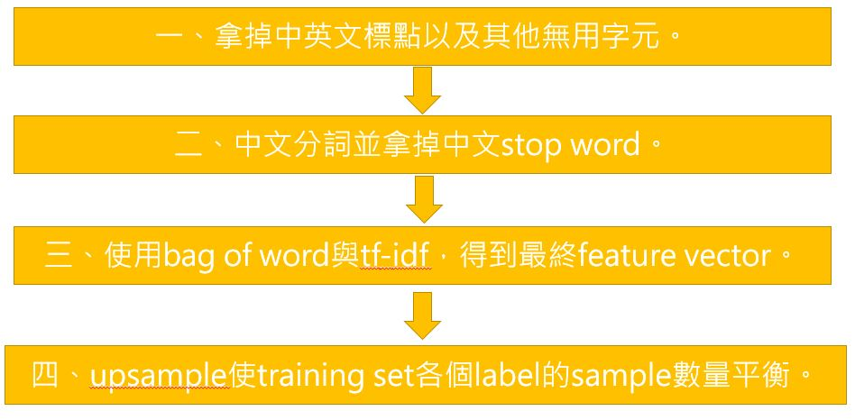

```python
from IPython.display import Image
Image(filename='image/專題預處理步驟.jpg', width=600)
```

#### label encoding的方式如下圖：

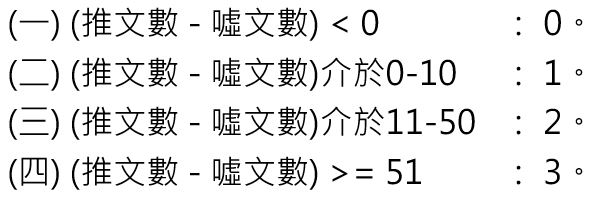

```python
from IPython.display import Image
Image(filename='image/label_encoding.jpg', width=400)
```

#### 接下來為預處理、萃取feature vector 與label encoding的程式說明：

#### 1. 拿掉中英文標點以及其他無用字元

```python
# preprocessing : extracting feature vector

import re
from zhon.hanzi import punctuation
import string

eng_punc = string.punctuation
def preprocessor(text):
    text = re.sub('\n', '', text)

    re_punctuation = "[{}]+".format(punctuation)  #拿掉中文標點
    text = re.sub(re_punctuation, "", text)

    re_punctuation_eng = "[{}]+".format(eng_punc) #拿掉英文標點
    text = re.sub(re_punctuation_eng, "", text)

    ptt_punc = '\n\t ※'
    re_punctuation_ptt = "[{}]+".format(ptt_punc) #拿掉其他無用字元
    text = re.sub(re_punctuation_ptt, "", text)

    text = re.sub('[0-9A-Za-z]+','',text)

    return text

for i in range(0, len(X)):
    X[i] = preprocessor(X[i])
```

#### 2. 中文分詞並拿掉中文stop word

```python
# preprocessing : 移除stop word
import jieba.analyse
import jieba

jieba.set_dictionary("jieba_dict/dict.txt.big.txt")
tags = []

for i in range(0, len(X)):
    tags.append(jieba.analyse.extract_tags(X[i], topK=50, withWeight=True))
stopWords = []
with open('stop_word/stop_word.txt', 'r', encoding='UTF-8') as file:
    for data in file.readlines():
        data = data.strip()
        stopWords.append(data)

X_cut = X
X_cut_stop = X

for i in range(0, len(X)):
    X_cut[i] = jieba.cut(X[i], cut_all=False)
    X_cut_stop[i] = list(filter(lambda a: a not in stopWords and a != '\n', X_cut[i]))
```

```
Building prefix dict from C:\Users\HP\Desktop\python_code\105061225_105061254\code\jieba_dict\dict.txt.big.txt ...
Loading model from cache C:\Users\HP\AppData\Local\Temp\jieba.u235963241ba676e9e2b010a6a19de547.cache
Loading model cost 7.273 seconds.
Prefix dict has been built succesfully.
```

#### 中文自然語言處理和英文自然語言處理最大的不同在於英文詞和詞之間會有空格但中文卻沒有，所以就有許多相對應演算法的誕生。

#### 在此我們使用jieba(結巴)分詞庫，jieba中文斷詞所使用的演算法是基於 Trie Tree 結構去生成句子中中文字所有可能成詞的情況，然後使用動態規劃算法來找出最大機率的路徑，這個路徑就是基於詞頻的最大斷詞結果。

#### 對於辨識新詞（字典詞庫中不存在的詞）則使用了 HMM 模型（Hidden Markov Model）及 Viterbi 算法來辨識出來。

#### 3. label encoding

```python
# preprocessing : labeling y_train
# encoding of 推噓 :
import math

for i in range(0, len(y)):
    if y[i] == '爆':
        y[i] = 3
    elif y[i][0] == 'X':
        y[i] = 0
    else:
        y[i] = int(y[i])
        if y[i] == 0:
            y[i] = 1
        elif y[i] >= 1 and y[i] <= 10:
            y[i] = 1
        elif y[i] >= 11 and y[i] <= 50:
            y[i] = 2
        elif y[i] >= 51 and y[i] <= 99:
            y[i] = 3
'''
for i in range(0, len(y)):
    if y[i] == '爆':
        y[i] = 1
    elif y[i][0] == 'X':
        y[i] = 0
    else:
        y[i] = int(y[i])
        if y[i] == 0:
            y[i] = 0
        elif y[i] >= 1 and y[i] <= 10:
            y[i] = 0
        elif y[i] >= 11 and y[i] <= 50:
            y[i] = 1
        elif y[i] >= 51 and y[i] <= 99:
            y[i] = 1
'''
```

[output not shown]

#### 4. 將文章轉成CountVectorizer可使用的型式

```python
# Preprocessing : 轉換成CountVectorizer可使用
import nltk
import numpy as np

X_cut_NTLK = []

for i in range(0, len(X)):
    article = ''
    for word in X_cut_stop[i]:
        article = article + word
        article = article + ' '
    X_cut_NTLK = np.hstack((X_cut_NTLK, article))
```

#### 經由jieba分詞後的文章必須經由以上的轉換才能使用CountVectorizer和TfidfTransformer做後續的處理

#### 5. train-test split(70%-30%)

```python
from sklearn.model_selection import train_test_split

y = y.astype('int')

X_train, X_test, y_train, y_test = train_test_split(
    X_cut_NTLK, y, test_size=0.3, random_state=1, stratify=y)

print('Labels counts in y:', np.bincount(y))
print('Labels counts in y_train:', np.bincount(y_train))
print('Labels counts in y_test:', np.bincount(y_test))
```

```
Labels counts in y: [ 131 2568  560  282]
Labels counts in y_train: [  92 1797  392  197]
Labels counts in y_test: [ 39 771 168  85]
```

#### 每一個label的sample數量不平衡，所以要對training set做upsample。

#### 6. 使用bag of word和tf-idf得到feature vector

```python
# Preprocessing : Bag of Word
# Preprocessing : Term frequency - inverse document frequency (tf - idf) using NTLK
from sklearn.feature_extraction.text import TfidfTransformer
from sklearn.feature_extraction.text import CountVectorizer

count = CountVectorizer(max_features=1000)
bag_train = count.fit_transform(X_train)
bag_test = count.transform(X_test)

tfidf = TfidfTransformer(use_idf = True,
                         norm = 'l2',
                         smooth_idf = True)
X_train = tfidf.fit_transform(bag_train)
X_test = tfidf.transform(bag_test)
print(X_train.shape[1])
```

```
1000
```

```python
print(y.shape[0])
print(X_train.shape[0])
print(X_test.shape[0])
```

```
3541
2478
1063
```

#### 7. resample使training set中每個label的sample數量相同

```python
print(len(X_train.toarray()[:,0]))
print(len(X_test.toarray()[:,0]))

X_all = np.concatenate((X_train.toarray(),X_test.toarray()),axis=0)
y_all = np.concatenate((y_train,y_test))

print(len(X_all[:,0]))
print(len(y_all))

group = np.zeros(len(y_all), dtype=np.int)
group[0:len(X_train.toarray()[:,0])] = group[0:len(X_train.toarray()[:,0])]+1
df_re = pd.DataFrame(X_all)
df_re['label'] = y_all
df_re['group'] = group
```

```
2478
1063
3541
3541
```

```python
from sklearn.utils import resample

df_0 = df_re[df_re.group==1][df_re.label==0]
df_1 = df_re[df_re.group==1][df_re.label==1]
df_2 = df_re[df_re.group==1][df_re.label==2]
df_3 = df_re[df_re.group==1][df_re.label==3]

df_0 = resample(df_0, replace=True, n_samples=np.bincount(y_train).max(), random_state=123)
df_1 = resample(df_1, replace=True, n_samples=np.bincount(y_train).max(), random_state=123)
df_2 = resample(df_2, replace=True, n_samples=np.bincount(y_train).max(), random_state=123)
df_3 = resample(df_3, replace=True, n_samples=np.bincount(y_train).max(), random_state=123)

df_upsampled = pd.concat([df_0, df_1,df_2, df_3])

X_train_up = np.asarray(df_upsampled.iloc[:,0:1000])
y_train_up = np.asarray(df_upsampled.iloc[:,1000])
X_test_up = np.asarray(df_re[df_re.group==0].iloc[:,0:1000])
y_test_up = np.asarray(df_re[df_re.group==0].iloc[:,1000])

print('train label 分布:',np.bincount(y_train_up))
print('test label 分布:',np.bincount(y_test_up))
print('評分標準(只猜一群):',len(y_test_up[y_test_up == 1])/len(y_test_up))
```

```
train label 分布: [1797 1797 1797 1797]
test label 分布: [ 39 771 168  85]
評分標準(只猜一群): 0.7253057384760113
```

### 五、專題內容 -- 使用一系列機器學習演算法

#### 1. 我們以logistic regression作為baseline

```python
# logistic regression using Scikit-learn
from sklearn.linear_model import LogisticRegression

lr = LogisticRegression(C = 10, random_state = 1)
lr.fit(X_train_up, y_train_up)

# Prediction and Performance Measurement
y_pred = lr.predict(X_test_up)
print('Misclassified samples: %d' % (y_test_up != y_pred).sum())
from sklearn.metrics import accuracy_score
print('Accuracy: %.2f' %accuracy_score(y_test_up, y_pred))
print('Accuracy: %.2f' %lr.score(X_test_up, y_test_up))

print('\ntest --- train\n')

# Prediction and Performance Measurement
y_pred2 = lr.predict(X_train_up)
print('Misclassified samples: %d' % (y_train_up != y_pred2).sum())
from sklearn.metrics import accuracy_score
print('Accuracy: %.2f' %accuracy_score(y_train_up, y_pred2))
print('Accuracy: %.2f' %lr.score(X_train_up, y_train_up))
```

```
Misclassified samples: 512
Accuracy: 0.52
Accuracy: 0.52

test --- train

Misclassified samples: 312
Accuracy: 0.96
Accuracy: 0.96
```

```python
print(np.bincount(y_pred))
```

```
[ 69 584 272 138]
```

```python
print(np.bincount(y_test))
```

```
[ 39 771 168  85]
```

```python
j = y_pred[y_pred != 1]
k = y_test_up[y_pred != 1]

print(sum(j==k)/(len(j)+1))  ## 小群的正確率
```

```
0.1875
```

#### 2. 接著試試SVM

```python
# training with SVM(RBF)
from sklearn.svm import SVC

svm = SVC(kernel = 'rbf', C = 100, gamma = 1000, random_state = 1)
svm.fit(X_train_up, y_train_up)

# Prediction and Performance Measurement
y_pred = svm.predict(X_test_up)
print('Misclassified samples: %d' % (y_test_up != y_pred).sum())
from sklearn.metrics import accuracy_score
print('Accuracy: %.2f' %accuracy_score(y_test_up, y_pred))
print('Accuracy: %.2f' %svm.score(X_test_up, y_test_up))

print('\ntest --- train\n')

# Prediction and Performance Measurement
y_pred2 = svm.predict(X_train_up)
print('Misclassified samples: %d' % (y_train_up != y_pred2).sum())
from sklearn.metrics import accuracy_score
print('Accuracy: %.2f' %accuracy_score(y_train_up, y_pred2))
print('Accuracy: %.2f' %svm.score(X_train_up, y_train_up))
```

```
Misclassified samples: 293
Accuracy: 0.72
Accuracy: 0.72

test --- train

Misclassified samples: 1
Accuracy: 1.00
Accuracy: 1.00
```

```python
print(np.bincount(y_pred))
```

```
[   0 1062    0    1]
```

```python
print(np.bincount(y_test))
```

```
[ 39 771 168  85]
```

```python
j = y_pred[y_pred != 1]
k = y_test_up[y_pred != 1]

print(sum(j==k)/(len(j)+1))  ## 小群的正確率
```

```
0.0
```

#### SVM的問題在明顯overfitting，而且幾乎只猜最大群，固然Accuracy比baseline高，但這是因為它都猜最大群。

#### 於是我們把目標放在提升小群的預測比例和整體準確度，所以我們想到bagging和boosting

#### 3. bagging

```python
# training with forest
from sklearn.ensemble import RandomForestClassifier

forest = RandomForestClassifier(criterion='entropy', n_estimators=500, random_state=1, n_jobs=-1)
forest.fit(X_train_up, y_train_up)

# Prediction and Performance Measurement
y_pred = forest.predict(X_test_up)
print('Misclassified samples: %d' % (y_test_up != y_pred).sum())
from sklearn.metrics import accuracy_score
print('Accuracy: %.2f' %accuracy_score(y_test_up, y_pred))
print('Accuracy: %.2f' %forest.score(X_test_up, y_test_up))

print('\ntest --- train\n')

# Prediction and Performance Measurement
y_pred2 = forest.predict(X_train_up)
print('Misclassified samples: %d' % (y_train_up != y_pred2).sum())
from sklearn.metrics import accuracy_score
print('Accuracy: %.2f' %accuracy_score(y_train_up, y_pred2))
print('Accuracy: %.2f' %forest.score(X_train_up, y_train_up))
```

```
Misclassified samples: 325
Accuracy: 0.69
Accuracy: 0.69

test --- train

Misclassified samples: 1
Accuracy: 1.00
Accuracy: 1.00
```

```python
print(np.bincount(y_pred))
```

```
[ 34 905  63  61]
```

```python
print(np.bincount(y_test))
```

```
[ 39 771 168  85]
```

```python
j = y_pred[y_pred != 1]
k = y_test_up[y_pred != 1]

print(sum(j==k)/(len(j)+1))  ## 小群的正確率
```

```
0.2641509433962264
```

#### bagging使用randomforest，可以觀察到相對SVM大幅解決只猜最大群的問題，且accuracy比logistic regression高。

#### 4. boosting

```python
from sklearn.ensemble import AdaBoostClassifier
from sklearn.tree import DecisionTreeClassifier

tree = DecisionTreeClassifier(max_depth=3, criterion='entropy', random_state=1)
ada = AdaBoostClassifier(base_estimator=tree, n_estimators=30, learning_rate=0.1, random_state=1)
ada = ada.fit(X_train_up,y_train_up)

# Prediction and Performance Measurement
y_pred = ada.predict(X_test_up)
print('Misclassified samples: %d' % (y_test_up != y_pred).sum())
from sklearn.metrics import accuracy_score
print('Accuracy: %.2f' %accuracy_score(y_test_up, y_pred))
print('Accuracy: %.2f' %ada.score(X_test_up, y_test_up))

print('\ntest --- train\n')

# Prediction and Performance Measurement
y_pred2 = ada.predict(X_train_up)
print('Misclassified samples: %d' % (y_train_up != y_pred2).sum())
from sklearn.metrics import accuracy_score
print('Accuracy: %.2f' %accuracy_score(y_train_up, y_pred2))
print('Accuracy: %.2f' %ada.score(X_train_up, y_train_up))
```

```
Misclassified samples: 412
Accuracy: 0.61
Accuracy: 0.61

test --- train

Misclassified samples: 2871
Accuracy: 0.60
Accuracy: 0.60
```

```python
print(np.bincount(y_pred))
```

```
[ 25 788  85 165]
```

```python
print(np.bincount(y_test))
```

```
[ 39 771 168  85]
```

```python
j = y_pred[y_pred != 1]
k = y_test_up[y_pred != 1]

print(sum(j==k)/(len(j)+1))  ## 小群的正確率
```

```
0.15942028985507245
```

#### boosting使用adaboost，與前者比較稍微犧牲準確度，但是針對小群的預測也更多，這是由於boosting的設計本來就是針對特例情況。但是也有缺點，訓練某些板時收斂速度極慢，至少要10個小時可能才符合需求。

#### 5. Multilayer perceptron(MLP)

```python
from sklearn.neural_network import MLPClassifier

mlp = MLPClassifier(random_state=1,hidden_layer_sizes=(100, ))
mlp.fit(X_train_up, y_train_up)

# Prediction and Performance Measurement
y_pred = mlp.predict(X_test_up)
print('Misclassified samples: %d' % (y_test_up != y_pred).sum())
from sklearn.metrics import accuracy_score
print('Accuracy: %.2f' %accuracy_score(y_test_up, y_pred))
print('Accuracy: %.2f' %mlp.score(X_test_up, y_test_up))

print('\ntest --- train\n')

# Prediction and Performance Measurement
y_pred2 = mlp.predict(X_train_up)
print('Misclassified samples: %d' % (y_train_up != y_pred2).sum())
from sklearn.metrics import accuracy_score
print('Accuracy: %.2f' %accuracy_score(y_train_up, y_pred2))
print('Accuracy: %.2f' %mlp.score(X_train_up, y_train_up))
```

```
Misclassified samples: 481
Accuracy: 0.55
Accuracy: 0.55

test --- train

Misclassified samples: 1
Accuracy: 1.00
Accuracy: 1.00
```

```python
print(np.bincount(y_pred))
```

```
[ 42 661 243 117]
```

```python
print(np.bincount(y_test))
```

```
[ 39 771 168  85]
```

```python
j = y_pred[y_pred != 1]
k = y_test_up[y_pred != 1]

print(sum(j==k)/(len(j)+1))  ## 小群的正確率
```

```
0.18610421836228289
```

#### 最後我們嘗試深度學習中的MLP。用最少的時間完成接近adaboost的accuracy且兼顧小群比例。

### 六、結果整理

#### 1. 首先是各個版的文字雲分析結果，可以看到不同的版之間關鍵字確實有明顯不同，不過也可以觀察到某些版之間有重疊的關鍵字

```python
# (Not necessary) : word cloud for training set
import numpy as np
import matplotlib.pyplot as plt
from wordcloud import WordCloud

cloud = ''

for i in range(0, len(X)):
    for word in X_cut_stop[i]:
        cloud = cloud + word
        cloud = cloud + ' '
```

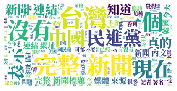

```python
# 產生文字雲
wc = WordCloud(font_path="word/NotoSerifCJKtc-Black.otf", #設置字體
               background_color="white", #背景顏色
               max_words = 2000)        #文字雲顯示最大詞數
wc.generate(cloud)

# 視覺化呈現
plt.imshow(wc)
plt.axis("off")
fig = plt.figure(figsize=(10,6), dpi = 100)
plt.show()
```

(1) 媽寶版(BabyMother board)

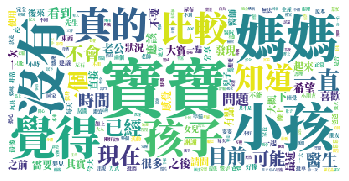

```python
Image(filename='image/baby_mother_wordcloud.png', width=600)
```

(2) 八卦版(Gossiping board)

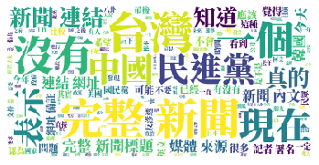

```python
Image(filename='image/gossiping_wordcloud.png', width=600)
```

(3) 政黑板(HatePolitics board)

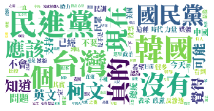

```python
Image(filename='image/hatepolitics_wordcloud.png', width=600)
```

(4) 韓星版(KoreaStar board)

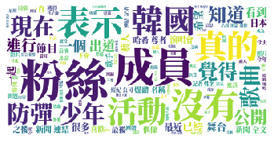

```python
Image(filename='image/koreastar_wordcloud.png', width=600)
```

(5) 省錢版(lifeismoney board)

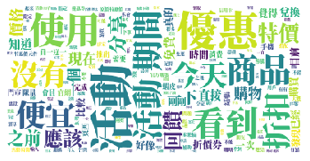

```python
Image(filename='image/lifeismoney_wordcloud.png', width=600)
```

(6) 婚姻版(marriage board)

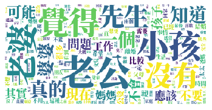

```python
Image(filename='image/marriage_wordcloud.png', width=600)
```

(7) 行動通訊/手機(mobilecomm board)

[figure not shown]

```python
Image(filename='image/mobilecomm_wordcloud.png', width=600)
```

(8) 電影版(movie board)

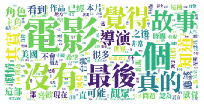

```python
Image(filename='image/movie_wordcloud.png', width=600)
```

(9) 西斯版(sex board)

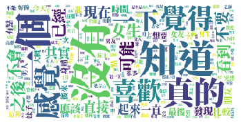

```python
Image(filename='image/sex_wordcloud.png', width=600)
```

(10) 股版(stock board)

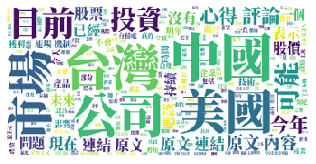

```python
Image(filename='image/stock_wordcloud.png', width=600)
```

(11) 女版(womantalk board)

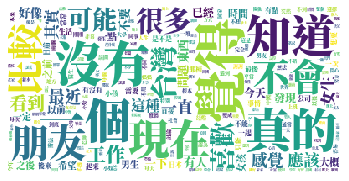

```python
Image(filename='image/womantalk_wordcloud.png', width=600)
```

#### 2. 各個版training model結果整理

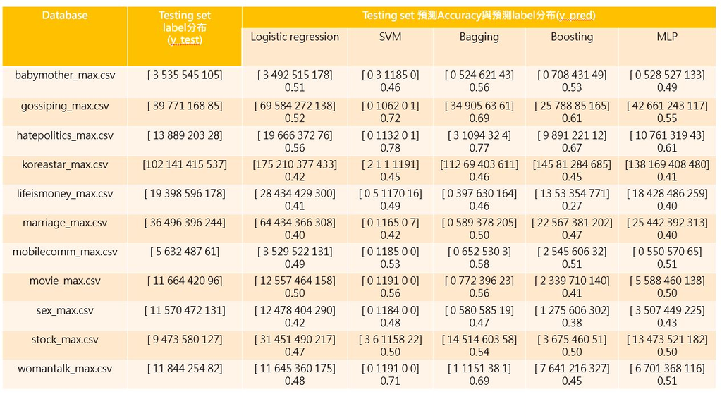

```python
Image(filename='image/專題結果.jpg', width=1000)
```

#### (3) 其中bagging使用random forest，效率高，但有時會有overfitting的問題。

#### (4) 其中boosting使用adaboost，由於是boosting所以較容易找到少數族群。

#### (5) NN的參數在使用預設值的狀況下就有不錯的accuracy，而且預測結果也兼顧小群比例，如果未來再調整參數或許會有更好的結果。

#### (6) 我們認為困難點在data來源是論壇文章，過於廣泛且具時效性，文筆也很難在字詞間判斷，而且很難定義出分布均勻且有意義的label適用各版。

### 七、未來展望

#### (1) 使用更多不同的深度學習演算法，例如：CNN、RNN。

#### (2) 使用其他特徵像是發文日期、時間、作者、分類......等等。

#### (3) 用不同版的model預測其他版的文章來看不同的版之間是否有共同特徵。例如從文字雲可以看的出來八卦版和政黑版有類似的關鍵字，或許拿八卦版的model來預測政黑版的文章會有不錯的結果。

#### (4) 使用除了bag of word和tfidf以外的方式來得到feature vector，使用上述兩種方式得到的feature vector最大的缺點是特徵矩陣為稀疏矩陣，會影響model的訓練時間，也可能會影響準確度。

### 1. 斷詞

#### NLTK 初學指南(一)：簡單易上手的自然語言工具箱－探索篇

#### [如何使用 jieba 結巴中文分詞程式](https://blog.fukuball.com/%E5%A6%82%E4%BD%95%E4%BD%BF%E7%94%A8-jieba-%E7%B5%90%E5%B7%B4%E4%B8%AD%E6%96%87%E5%88%86%E8%A9%9E%E7%A8%8B%E5%BC%8F/)

#### 以 jieba 與 gensim 探索文本主題：五月天人生無限公司歌詞分析 ( I )

### 2. jieba github

#### [original jieba github](https://github.com/LiveMirror/jieba)

#### [Taiwan jieba github](https://github.com/ldkrsi/jieba-zh_TW)

### 3. csv_read for Chinese

#### [pandas read_csv(中文名称 中文路径)](https://blog.csdn.net/aaa_aaa1sdf/article/details/77411314)

### 4. 拿掉標點符號

#### [jieba分詞，並去除所有標點](https://www.itread01.com/content/1541772003.html)

#### [zhon包](https://zhon.readthedocs.io/en/latest/#)

#### [拿掉標點方法](https://www.itread01.com/article/1526265090.html)

### 5. 文字雲

#### [python（wordcloud）實現中文詞雲](https://www.itread01.com/content/1531395536.html)

### 6. NLTK

#### NLTK 初學指南(一)：簡單易上手的自然語言工具箱－探索篇

### 7. 移除中文停用自

#### [10-2 中文斷詞-移除停用詞](https://github.com/tomlinNTUB/Python-in-5-days/blob/master/10-2%20%E4%B8%AD%E6%96%87%E6%96%B7%E8%A9%9E-%E7%A7%BB%E9%99%A4%E5%81%9C%E7%94%A8%E8%A9%9E.md)

### 8. 流程

#### [NLP入门-- 文本预处理Pre-processing](https://zhuanlan.zhihu.com/p/53277723)

### 9. 關於NLP

#### [進入NLP 世界的最佳橋樑：寫給所有人的自然語言處理與深度學習入門指南](https://leemeng.tw/shortest-path-to-the-nlp-world-a-gentle-guide-of-natural-language-processing-and-deep-learning-for-everyone.html)

#### [Practical Text Classification With Python and Keras](https://realpython.com/python-keras-text-classification/?fbclid=IwAR1qlyDQ9MJezGx3IAB4QKlG8ppAU4qOe2Kg9DdbQyQVoutzCktOHLxJwIQ)

### 10. 深度學習

#### [sklearn.neural_network.MLPClassifier](https://scikit-learn.org/stable/modules/generated/sklearn.neural_network.MLPClassifier.html)

#### [Convolutional Neural Network (CNN)](https://www.tensorflow.org/tutorials/images/cnn)

#### [Deep Learning:An MIT Press book / Ian Goodfellow and Yoshua Bengio and Aaron Courville](http://www.deeplearningbook.org/)